# NOAAStormAnalysis

SungChan Lee

Feb 8 2016

## Type of events most harful with respect to polulation health

### Synopsis

*NOAA(National Oceanic and Atmospheric Advministration) storm database has characteristics of major storms and weather events in the United States. The goal of this analysis is to find out what is the most health threatining event and what event has most serious economic effect. To find out the event affect on the population heath, fatality and injury data is summed by event type. To figure out the economic effect, numeric calcuation has been performed to convert exponential code into actual values. Three plots are provided to visualize the analysis result. The result shows Tonado is the most significant event for fatalities and injuries. On contrary the highst event for economic damage is Flood (Tonado is the 3rd event)*

### Data Processing

This line is requred to prevent following error  
“Warning message:In scan(file, what, nmax, sep, dec, quote, skip, nlines, na.strings, : EOF within quoted string”"

```r
library(ggplot2)
Sys.setlocale("LC_ALL", "English")
```

```
## [1] "LC_COLLATE=English_United States.1252;LC_CTYPE=English_United States.1252;LC_MONETARY=English_United States.1252;LC_NUMERIC=C;LC_TIME=English_United States.1252"
```

When we download or unzip data, it is required to check if there is already data to avoid repeating unnecessary work.

```r
#cache zipped file
if(!file.exists("stormdata.csv.bz2")) {
  download.file("https://d396qusza40orc.cloudfront.net/repdata%2Fdata%2FStormData.csv.bz2", destfile = "stormdata.csv.bz2")
}

#cache uncompressed file
if(!file.exists("stormdata.csv"))
  bunzip2("stormdata.csv.bz2", remove="FALSE")

#cache data
if(!exists("raw_storm_data"))
  raw_storm_data <- read.csv("stormdata.csv")
```

### Filter out unused columns through this project

```r
#filter necessary columns
storm_data <- raw_storm_data[,c('EVTYPE','FATALITIES','INJURIES', 'PROPDMG', 'PROPDMGEXP', 'CROPDMG', 'CROPDMGEXP')]

#print (head(storm_data))
```

### Count fatalities and injuries for each event type

```r
#count fatalities per event type
fatal <- aggregate(FATALITIES~EVTYPE, data=storm_data, FUN=sum, na.rm=TRUE, na.action=NULL)
fatal <- fatal[order(fatal$FATALITIES, decreasing=TRUE), ]
fatal.top5 <- head(fatal, 5)
fatal.top5
```

```
##             EVTYPE FATALITIES
## 834        TORNADO       5633
## 130 EXCESSIVE HEAT       1903
## 153    FLASH FLOOD        978
## 275           HEAT        937
## 464      LIGHTNING        816
```

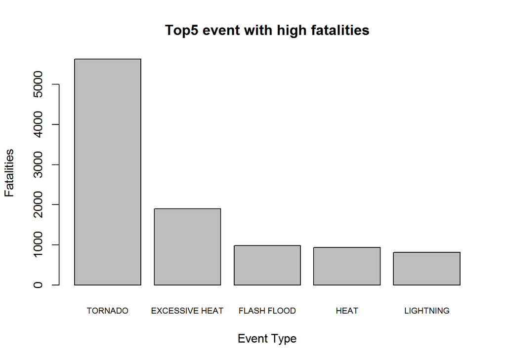

```r
barplot(fatal.top5$FATALITIES, names.arg = fatal.top5$EVTYPE, xlab="Event Type", ylab="Fatalities", cex.names=0.7, main="Top5 event with high fatalities")
```

```r
#count injury per event type
injury <- aggregate(INJURIES~EVTYPE, data = storm_data, FUN=sum, na.rm=TRUE, na.action=NULL)
injury <- injury[order(injury$INJURIES, decreasing=TRUE), ]
injury.top5 <- head(injury, 5)
injury.top5
```

```
##             EVTYPE INJURIES
## 834        TORNADO    91346
## 856      TSTM WIND     6957
## 170          FLOOD     6789
## 130 EXCESSIVE HEAT     6525
## 464      LIGHTNING     5230
```

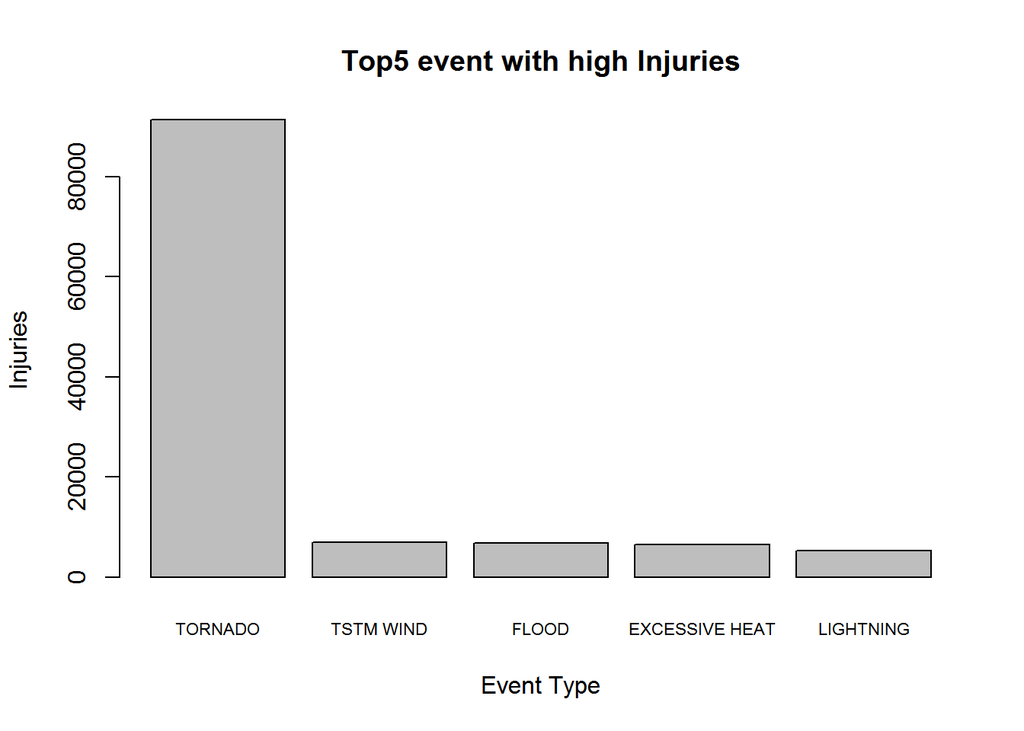

```r
barplot(injury.top5$INJURIES, names.arg = injury.top5$EVTYPE, xlab="Event Type", ylab="Injuries", cex.names=0.7, main="Top5 event with high Injuries")
```

### Result

**Barplot shows that Tonado has the most significant effect on the population health**

## Type of event have the greatest economic consequences

First of all, we should check how damage data is described

```r
## check what levels are
print(unique(storm_data$PROPDMGEXP))
```

```
##  [1] K M   B m + 0 5 6 ? 4 2 3 h 7 H - 1 8
## Levels:  - ? + 0 1 2 3 4 5 6 7 8 B h H K m M
```

```r
print(unique(storm_data$CROPDMGEXP))
```

```
## [1]   M K m B ? 0 k 2
## Levels:  ? 0 2 B k K m M
```

According to the observation, we should convert exponential code into exponential value

```r
print(unique(storm_data$PROPDMGEXP))
```

[output not shown]

```r
print(unique(storm_data$CROPDMGEXP))
```

[output not shown]

### We should calculate total damage

```r
#calculate damage
storm_data$TOTALDMG <- as.numeric(storm_data$PROPDMG) * (10 ^ as.numeric(storm_data$PROPDMGEXP)) + as.numeric(storm_data$CROPDMG) * (10 ^ as.numeric(storm_data$CROPDMGEXP))
```

### Bar plot top5

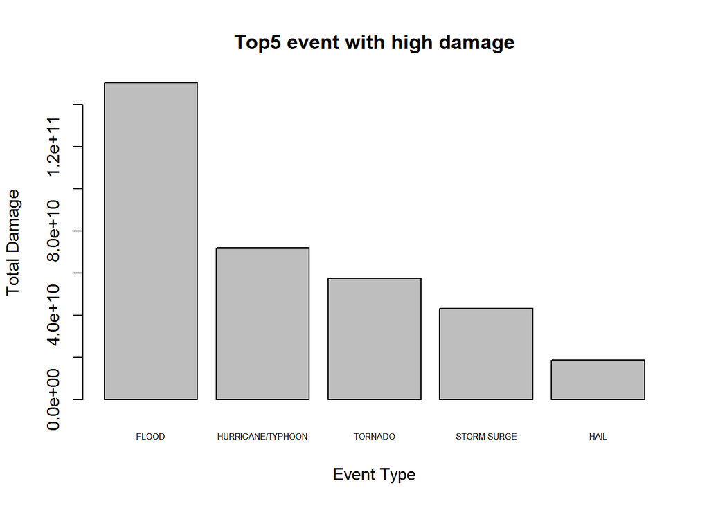

### Result

**Flood is the event with the highst damage**